# F₂ Genetic Map

- Show All Code
- Hide All Code
- View Source

QTL series notebook 2 — the linkage map: 1,152 markers, 1,858 cM, CML530 coordinates

Author

Fausto Rodriguez Zapata

Published

July 31, 2026

**QTL series — notebook 2.** Follows marker QC and ABH encoding. The full protocol with every parameter and its basis is in `scripts/qtl/PROTOCOL.md`.

**Note**

**This notebook reads only public data.** The raw DArTseq genotypes are not redistributable and are gitignored, but the map itself — marker names, linkage group, genetic position and both coordinate systems — is published as [`data/f2_genetic_map.tsv`](https://github.com/faustovrz/gcamoz/blob/main/data/f2_genetic_map.tsv). Everything below is reproduced from that file alone.

# 1 What this map is

A single biparental F₂ (186 genotyped plants, DArTseq order `DMz26-3123`) from the 7 × 7 line × tester programme. **CML530 is the female parent** — established by the design, not assumed. The male is one of the seven `EN` testers; which one is still unknown and matters only for the sign of allele effects.

**Positions are CML530’s own**, from `Zm-CML530-REFERENCE-HiLo-1.0`. B73 is not a parent of this cross, and the two assemblies disagree about which chromosome carries a marker for 37 of them. Because `est.map` estimates distances along a *fixed* order and never reorders, a wrong order cannot be recovered downstream — so the order comes from a real parent of the cross. B73 v5 coordinates are carried alongside for cross-referencing.

```r
library(data.table)
library(ggplot2)
library(knitr)
map <- fread("data/f2_genetic_map.tsv")
map[, lg := factor(lg, levels = 1:10)]
theme_set(theme_classic(base_size = 12))
```

# 2 Summary

Reference lengths come from the **Coe 2008 composite maize genetic map** projected to B73 v5 (`zealhmm/data/teonam/map_v5_coe2008.tsv`, 51,065 markers).

```r
CML_LEN <- c(`1` = 312749524, `2` = 253527201, `3` = 248930463, `4` = 258114092,
             `5` = 226836904, `6` = 187680145, `7` = 184149065, `8` = 188635608,
             `9` = 166200635, `10` = 153755684)
s <- map[, .(markers = .N,
             cM = round(max(cM), 1),
             mean_gap_cM = round(max(cM) / (.N - 1), 3),
             first_Mb = round(min(cml_pos) / 1e6, 1),
             last_Mb  = round(max(cml_pos) / 1e6, 1)), by = lg]
s[, chr_Mb := round(CML_LEN[as.character(lg)] / 1e6, 1)]
s[, span_Mb := round(last_Mb - first_Mb, 1)]
s[, pct_covered := round(100 * span_Mb / chr_Mb, 1)]
setorder(s, lg)
kable(s, caption = "The map by linkage group. Coverage is the span of mapped markers against the CML530 chromosome length; lost ends are regions where a QTL cannot be found.")
```

Table 1: The map by linkage group. Coverage is the span of mapped markers against the CML530 chromosome length; lost ends are regions where a QTL cannot be found.

| lg | markers | cM | mean_gap_cM | first_Mb | last_Mb | chr_Mb | span_Mb | pct_covered |
| --- | --- | --- | --- | --- | --- | --- | --- | --- |
| 1 | 165 | 267.9 | 1.633 | 4.7 | 309.7 | 312.7 | 305.0 | 97.5 |
| 2 | 180 | 251.2 | 1.403 | 0.4 | 252.8 | 253.5 | 252.4 | 99.6 |
| 3 | 126 | 174.5 | 1.396 | 5.8 | 247.5 | 248.9 | 241.7 | 97.1 |
| 4 | 122 | 174.0 | 1.438 | 0.9 | 256.8 | 258.1 | 255.9 | 99.1 |
| 5 | 119 | 192.9 | 1.635 | 0.8 | 225.5 | 226.8 | 224.7 | 99.1 |
| 6 | 77 | 140.4 | 1.848 | 34.3 | 185.8 | 187.7 | 151.5 | 80.7 |
| 7 | 93 | 189.8 | 2.063 | 1.5 | 182.5 | 184.1 | 181.0 | 98.3 |
| 8 | 114 | 148.0 | 1.310 | 4.0 | 186.2 | 188.6 | 182.2 | 96.6 |
| 9 | 87 | 168.2 | 1.956 | 1.9 | 164.6 | 166.2 | 162.7 | 97.9 |
| 10 | 69 | 151.5 | 2.228 | 1.0 | 153.1 | 153.8 | 152.1 | 98.9 |

```r
cat(sprintf("total: %d markers, %.1f cM, %.1f%% physical coverage (%.0f of %.0f Mb)\n",
            nrow(map), sum(s$cM), 100 * sum(s$span_Mb) / sum(s$chr_Mb),
            sum(s$span_Mb), sum(s$chr_Mb)))
```

```
total: 1152 markers, 1858.4 cM, 96.7% physical coverage (2109 of 2180 Mb)
```

## 2.1 Length against the Coe 2008 composite

```r
COE <- c(`1` = 285.7, `2` = 181.6, `3` = 207.7, `4` = 187.2, `5` = 170.5,
         `6` = 137.3, `7` = 156.0, `8` = 159.0, `9` = 160.2, `10` = 135.9)
cmp <- copy(s)[, .(lg, f2_cM = cM)]
cmp[, coe_cM := COE[as.character(lg)]]
cmp[, ratio := round(f2_cM / coe_cM, 3)]
kable(cmp[order(lg)], caption = "This map against the Coe 2008 composite maize genetic map, per linkage group.")
cat(sprintf("total: F2 %.1f cM vs Coe %.1f cM  ->  ratio %.3f\n",
            sum(cmp$f2_cM), sum(cmp$coe_cM), sum(cmp$f2_cM) / sum(cmp$coe_cM)))
```

```
total: F2 1858.4 cM vs Coe 1781.1 cM  ->  ratio 1.043
```

Table 2: This map against the Coe 2008 composite maize genetic map, per linkage group.

| lg | f2_cM | coe_cM | ratio |
| --- | --- | --- | --- |
| 1 | 267.9 | 285.7 | 0.938 |
| 2 | 251.2 | 181.6 | 1.383 |
| 3 | 174.5 | 207.7 | 0.840 |
| 4 | 174.0 | 187.2 | 0.929 |
| 5 | 192.9 | 170.5 | 1.131 |
| 6 | 140.4 | 137.3 | 1.023 |
| 7 | 189.8 | 156.0 | 1.217 |
| 8 | 148.0 | 159.0 | 0.931 |
| 9 | 168.2 | 160.2 | 1.050 |
| 10 | 151.5 | 135.9 | 1.115 |

Within 4.3 % of the composite overall. chr2 is the least consistent at 1.38 and chr3 at 0.84; the rest sit between 0.93 and 1.22. A single F₂ against a composite of many populations will not match chromosome by chromosome, so the total is the meaningful comparison.

# 3 Ideogram

Each horizontal line is one marker. Solid black, no transparency — this map is sparse enough that individual markers should be readable rather than blended into a density.

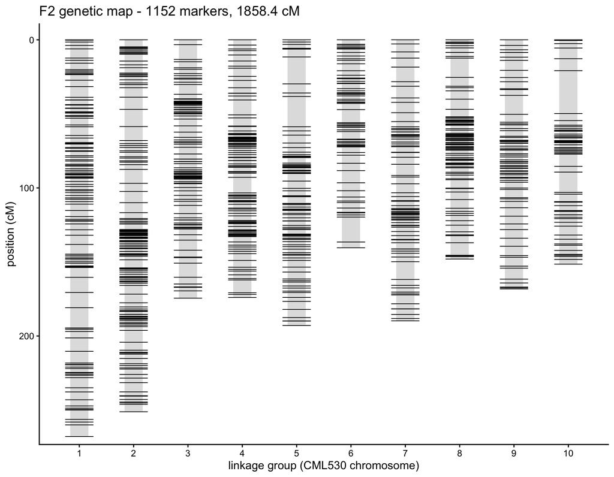

Figure 1: Marker positions on the ten linkage groups. Every marker is drawn as an opaque black tick.

```r
W <- 0.26   # half-width of the bar, in x units
map[, xn := as.numeric(lg)]
s[,   xn := as.numeric(lg)]
ggplot() +
  geom_segment(data = s, aes(x = xn, xend = xn, y = 0, yend = cM),
               linewidth = 9, colour = "grey88", lineend = "butt") +
  geom_segment(data = map, aes(x = xn - W, xend = xn + W, y = cM, yend = cM),
               linewidth = 0.35, colour = "black") +
  scale_x_continuous(breaks = 1:10, labels = 1:10) +
  scale_y_reverse(expand = expansion(mult = c(0.02, 0.04))) +
  labs(x = "linkage group (CML530 chromosome)", y = "position (cM)",
       title = sprintf("F2 genetic map - %d markers, %.1f cM", nrow(map), sum(s$cM)))
```